# Classifying Term Deposit Subscriptions Using Machine Learning

Aiden Liu

# Variable Description

-age

-job - type of job (categorical:‘admin.’,‘blue-collar’,‘entrepreneur’,‘housemaid’,‘management’,‘retired’,‘self-employed’,‘services’,‘student’,‘technician’,‘unemployed’,‘unknown’)

-marital - marital status (categorical: ‘divorced’,‘married’,‘single’,‘unknown’; note: ‘divorced’ means divorced or widowed)

-education - (categorical: ‘basic.4y’,‘basic.6y’,‘basic.9y’,‘high.school’,‘illiterate’,‘professional.course’,‘university.degree’,‘unknown’)

-default - has credit in default?

-balance - average yearly balance

-housing - has housing loan?

-loan - has personal loan?

-contact - contact communication type (categorical: ‘cellular’,‘telephone’)

-day_of_week - last contact day of the week

-month - last contact month of year (categorical: ‘jan’, ‘feb’, ‘mar’, …, ‘nov’, ‘dec’)

-duration - last contact duration, in seconds (numeric)

-day - date of the month

-campaign - number of contacts performed during this campaign and for this client (numeric, includes last contact)

-pdays - number of days that passed by after the client was last contacted from a previous campaign (numeric; -1 means client was not previously contacted)

-previous - number of contacts performed before this campaign and for this client

-poutcome - outcome of the previous marketing campaign (categorical: ‘failure’,‘nonexistent’,‘success’)

-y - has the client subscribed a term deposit?

# Libraries

```r
library(readr)
library(dplyr)
library(rpart)
library(rpart.plot)
library(randomForest)
library(caret)
library(caTools)
library(pROC)
library(car)
library(glmnet)
library(gbm)
```

# Reading in the data

```r
bank.data = read_delim("bank.csv", delim = ";",
    escape_double = FALSE, trim_ws = TRUE)
```

Inspecting the class of each variable

```r
sapply(bank.data, class)
```

```
##         age         job     marital   education     default     balance
##   "numeric" "character" "character" "character" "character"   "numeric"
##     housing        loan     contact         day       month    duration
## "character" "character" "character"   "numeric" "character"   "numeric"
##    campaign       pdays    previous    poutcome           y
##   "numeric"   "numeric"   "numeric" "character" "character"
```

Adjusting all binary and character variables into factors

```r
cat_vars = c("default", "housing", "loan", "y", "job", "marital", "education", "contact", "month", "poutcome")
bank.data[cat_vars] = lapply(bank.data[cat_vars], factor)
```

```r
all((bank.data$pdays == -1) == (bank.data$poutcome == "unknown"))   # TRUE means they are the same set of rows
```

```
## [1] TRUE
```

```r
sapply(bank.data,class)
```

```
##       age       job   marital education   default   balance   housing      loan
## "numeric"  "factor"  "factor"  "factor"  "factor" "numeric"  "factor"  "factor"
##   contact       day     month  duration  campaign     pdays  previous  poutcome
##  "factor" "numeric"  "factor" "numeric" "numeric" "numeric" "numeric"  "factor"
##         y
##  "factor"
```

Checking for any NA values in the dataset

```r
any(is.na(bank.data)) # Finding if there are any NA values in our dataset
```

```
## [1] FALSE
```

Remove unnecessary column

```r
bank.data$day = NULL # Removing date of the month
```

A large number of previous number of days that passed by after the client was last contacted from a previous campaign are -1, indicating most of the clients have not been contacted before. Therefore, I will remove pdays.

```r
bank.data$pdays = NULL
```

Also note, ‘duration’ does not tell us who to call in order to improve the likelihood of a customer saying yes to our term deposit scheme.

```r
bank.data$duration = NULL
```

Splitting the data into training and test sets

```r
set.seed(893)
# Splitting data in train and test data
split = sample.split(bank.data$y, SplitRatio = 0.7) # 70-30 split for training vs test set

train.data = subset(bank.data, split == "TRUE") # Subsetting dataset into training set
test.data = subset(bank.data, split == "FALSE") # Subsetting dataset into test set
test.y = test.data$y
```

Is the dataset imbalanced?

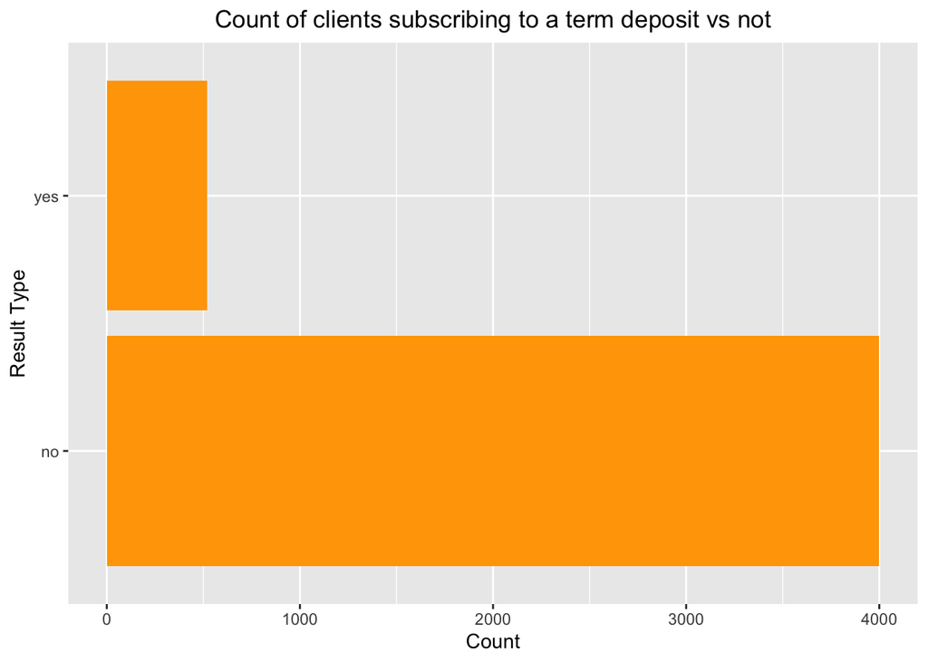

```r
ggplot(data = bank.data, mapping = aes(y=y))+
  geom_bar(fill="orange")+
  labs(x="Count", y="Result Type", title="Count of clients subscribing to a term deposit vs not")+
    theme(plot.title = element_text(hjust = 0.5))
```

Massively imbalanced dataset where there more negative case is the majority class, and the positive case is the minority class.

Fitting a decision tree with all possible variables

```r
tree_model = rpart(y~ ., data = train.data, method = "class")
```

Creating predictions and confusion matrix based on the decision tree

```r
predictions = predict(tree_model, newdata = test.data, type = "class") # Predictions

conf_matrix = confusionMatrix(predictions, test.y) # Building Confusion matrix
print(conf_matrix$byClass)
```

```
##          Sensitivity          Specificity       Pos Pred Value
##            0.9916667            0.1666667            0.9015152
##       Neg Pred Value            Precision               Recall
##            0.7222222            0.9015152            0.9916667
##                   F1           Prevalence       Detection Rate
##            0.9444444            0.8849558            0.8775811
## Detection Prevalence    Balanced Accuracy
##            0.9734513            0.5791667
```

How about a Logistic Regression method? Logistic Regression delivers highly interpretable probability scores even with high-dimensional data, effectively maps feature relationships without requiring massive computational power, eliminates the risk of complex black-box predictions, and reduces the risk of overfitting by incorporating regularization techniques like L1 or L2 penalties.

```r
first.model = glm(y~., data = train.data, family="binomial")
summary(first.model)
```

```
##
## Call:
## glm(formula = y ~ ., family = "binomial", data = train.data)
##
## Coefficients:
##                      Estimate Std. Error z value Pr(>|z|)
## (Intercept)        -1.415e+00  5.520e-01  -2.563  0.01036 *
## age                -3.491e-03  7.488e-03  -0.466  0.64112
## jobblue-collar     -5.711e-02  2.451e-01  -0.233  0.81574
## jobentrepreneur     2.447e-01  3.852e-01   0.635  0.52523
## jobhousemaid        1.652e-01  4.302e-01   0.384  0.70087
## jobmanagement       1.389e-01  2.539e-01   0.547  0.58443
## jobretired          8.393e-01  3.260e-01   2.575  0.01002 *
## jobself-employed    1.746e-02  3.654e-01   0.048  0.96188
## jobservices        -1.208e-01  2.882e-01  -0.419  0.67518
## jobstudent         -1.246e-01  4.447e-01  -0.280  0.77927
## jobtechnician      -2.405e-01  2.419e-01  -0.994  0.32018
## jobunemployed      -1.894e-01  4.363e-01  -0.434  0.66424
## jobunknown          5.552e-01  5.777e-01   0.961  0.33652
## maritalmarried     -5.287e-01  1.852e-01  -2.855  0.00430 **
## maritalsingle      -7.740e-02  2.128e-01  -0.364  0.71603
## educationsecondary  2.750e-01  2.079e-01   1.323  0.18599
## educationtertiary   2.008e-01  2.444e-01   0.822  0.41128
## educationunknown   -3.202e-01  3.888e-01  -0.824  0.41007
## defaultyes          4.374e-02  4.907e-01   0.089  0.92898
## balance            -1.491e-05  2.078e-05  -0.718  0.47290
## housingyes         -1.080e-01  1.443e-01  -0.748  0.45419
## loanyes            -4.358e-01  2.029e-01  -2.148  0.03171 *
## contacttelephone    2.323e-02  2.365e-01   0.098  0.92177
## contactunknown     -1.307e+00  2.321e-01  -5.632 1.78e-08 ***
## monthaug           -3.065e-01  2.559e-01  -1.197  0.23116
## monthdec            8.166e-01  6.839e-01   1.194  0.23247
## monthfeb           -1.820e-01  2.933e-01  -0.621  0.53477
## monthjan           -1.006e+00  3.897e-01  -2.581  0.00986 **
## monthjul           -8.505e-01  2.672e-01  -3.183  0.00146 **
## monthjun            4.337e-01  3.004e-01   1.444  0.14885
## monthmar            3.908e-01  4.619e-01   0.846  0.39755
## monthmay           -5.282e-01  2.329e-01  -2.268  0.02332 *
## monthnov           -6.985e-01  2.783e-01  -2.510  0.01208 *
## monthoct            9.542e-01  3.465e-01   2.754  0.00590 **
## monthsep            2.028e-01  4.523e-01   0.448  0.65389
## campaign           -5.512e-02  2.909e-02  -1.895  0.05805 .
## previous            6.210e-02  4.394e-02   1.413  0.15757
## poutcomeother       8.214e-01  2.768e-01   2.968  0.00300 **
## poutcomesuccess     2.338e+00  2.973e-01   7.864 3.73e-15 ***
## poutcomeunknown     2.973e-01  2.351e-01   1.264  0.20606
## ---
## Signif. codes:  0 '***' 0.001 '**' 0.01 '*' 0.05 '.' 0.1 ' ' 1
##
## (Dispersion parameter for binomial family taken to be 1)
##
##     Null deviance: 2263.0  on 3164  degrees of freedom
## Residual deviance: 1945.7  on 3125  degrees of freedom
## AIC: 2025.7
##
## Number of Fisher Scoring iterations: 6
```

```r
exp(coef(first.model))
```

```
##        (Intercept)                age     jobblue-collar    jobentrepreneur
##          0.2429450          0.9965156          0.9444946          1.2772494
##       jobhousemaid      jobmanagement         jobretired   jobself-employed
##          1.1796819          1.1489585          2.3148462          1.0176156
##        jobservices         jobstudent      jobtechnician      jobunemployed
##          0.8862309          0.8828204          0.7862443          0.8274511
##         jobunknown     maritalmarried      maritalsingle educationsecondary
##          1.7423648          0.5893841          0.9255190          1.3165268
##  educationtertiary   educationunknown         defaultyes            balance
##          1.2223495          0.7259725          1.0447092          0.9999851
##         housingyes            loanyes   contacttelephone     contactunknown
##          0.8976542          0.6467653          1.0235031          0.2705996
##           monthaug           monthdec           monthfeb           monthjan
##          0.7360454          2.2628419          0.8335681          0.3657826
##           monthjul           monthjun           monthmar           monthmay
##          0.4271904          1.5428924          1.4781774          0.5896482
##           monthnov           monthoct           monthsep           campaign
##          0.4973364          2.5966143          1.2247986          0.9463671
##           previous      poutcomeother    poutcomesuccess    poutcomeunknown
##          1.0640693          2.2737797         10.3577541          1.3461822
```

Let’s check for multicollinearity

```r
vif(first.model)
```

```
##               GVIF Df GVIF^(1/(2*Df))
## age       2.121365  1        1.456491
## job       4.815057 11        1.074057
## marital   1.439797  2        1.095406
## education 2.541162  3        1.168168
## default   1.028981  1        1.014387
## balance   1.061117  1        1.030105
## housing   1.450467  1        1.204353
## loan      1.051597  1        1.025474
## contact   1.978806  2        1.186044
## month     3.615229 11        1.060156
## campaign  1.104850  1        1.051118
## previous  2.025191  1        1.423092
## poutcome  2.468901  3        1.162565
```

Consider performing Lasso Regularisation to tackle overfitting

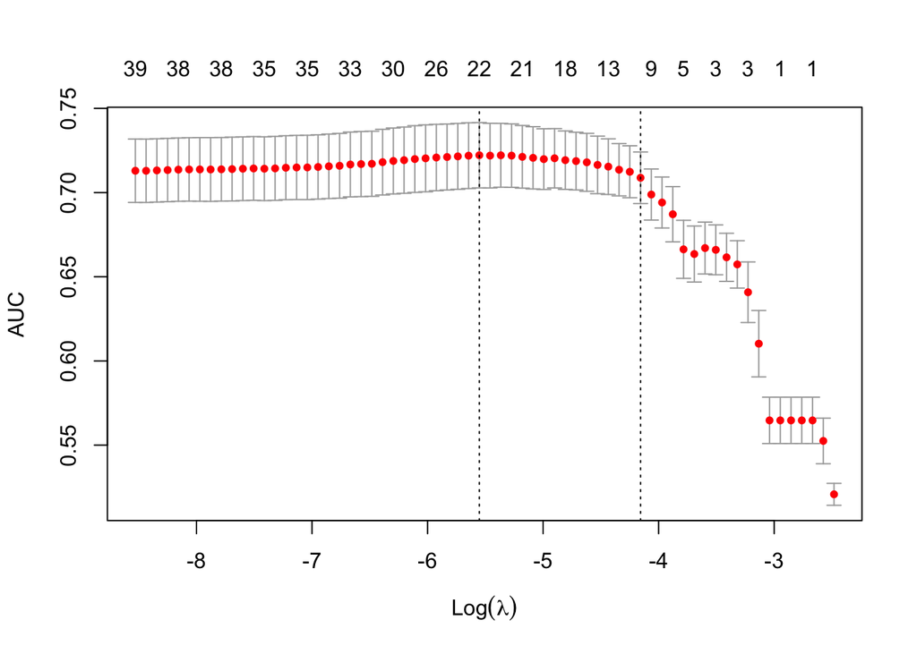

```r
x = model.matrix(y ~ ., train.data)[, -1] #dummy code factors
cv = cv.glmnet(x, as.integer(train.data$y == "yes"), family = "binomial",
                alpha = 1, type.measure = "auc", nfolds = 10)
plot(cv)
```

```r
p = predict(cv, model.matrix(y ~ ., test.data)[, -1], s = "lambda.min", type = "response")
auc(roc(test.data$y, p, levels = c("no", "yes")))
```

```
## Area under the curve: 0.7367
```

What about a Random Forest model?

```r
set.seed(893)
rf_fit = randomForest(y ~ ., data = train.data,
                      ntree = 500,        # number of trees
                      importance = TRUE)  # needed for the importance plot

# Predicted probability of "yes" on the test set
p_rf = predict(rf_fit, newdata = test.data, type = "prob")[, "yes"]

auc(roc(test.data$y, p_rf, levels = c("no", "yes")))
```

```
## Area under the curve: 0.7458
```

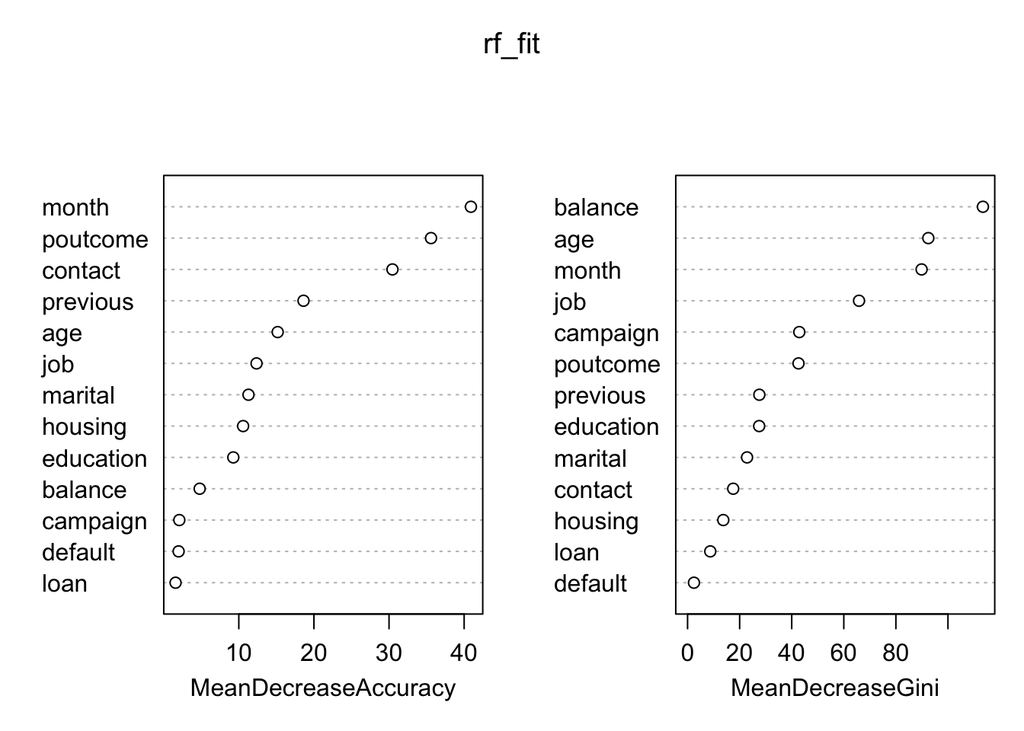

```r
varImpPlot(rf_fit)   # which variables matter most
```

0.74 AUC is decent. Let’s see if we can do better using a gradient boosting model.

Building a GBM

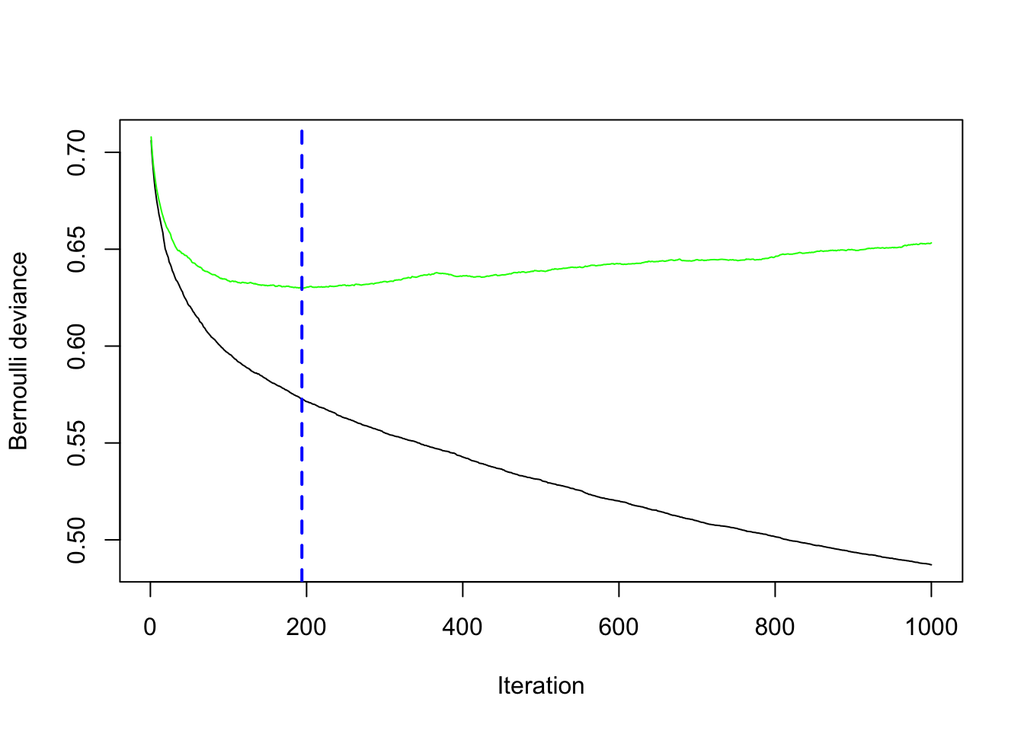

```r
# gbm needs a 0/1 numeric outcome (not a factor)
train.data$y01 = as.integer(train.data$y == "yes")
test.data$y01 = as.integer(test.data$y == "yes")

set.seed(893)
gbm_fit = gbm(y01 ~ . - y,                      # "- y" keeps the original label out of the predictors
               data = train.data,
               distribution = "bernoulli",       # binary outcome (logistic loss)
               n.trees = 1000,                   # maximum number of trees
               interaction.depth = 2,            # size of each tree
               shrinkage = 0.05,                 # learning rate
               n.minobsinnode = 20,              # minimum rows in a leaf
               bag.fraction = 0.7,               # each tree uses a random 70% of rows
               cv.folds = 5,                     # cross-validation to choose the number of trees
               verbose = FALSE)

best_trees = gbm.perf(gbm_fit, method = "cv")   # plot of CV error; returns the best tree count
```

```r
best_trees                                       # should be well below 1000
```

```
## [1] 194
```

```r
p1 = predict(gbm_fit, test.data, n.trees = best_trees, type = "response")
auc(roc(test.data$y, p1, levels = c("no", "yes")))
```

```
## Area under the curve: 0.7481
```

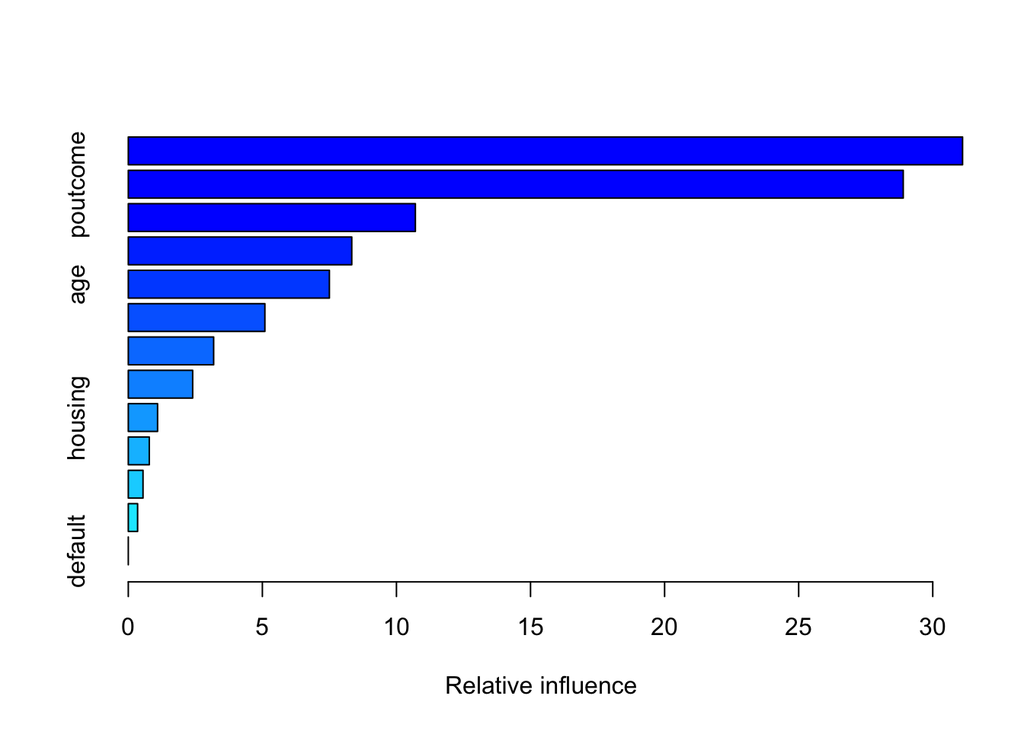

```
##                 var    rel.inf
## month         month 31.1117462
## poutcome   poutcome 28.8994194
## balance     balance 10.7056986
## job             job  8.3339032
## age             age  7.4993519
## contact     contact  5.0941320
## previous   previous  3.1833544
## marital     marital  2.4009201
## housing     housing  1.0921820
## campaign   campaign  0.7828723
## loan           loan  0.5492142
## education education  0.3472056
## default     default  0.0000000
```

```r
summary(gbm_fit, n.trees = best_trees)           # variable importance
```

0.75 (2sf) AUC is the limit with this dataset it seems.

# Final model

```r
# Final model
print(gbm_fit)
```

```
## gbm(formula = y01 ~ . - y, distribution = "bernoulli", data = train.data,
##     n.trees = 1000, interaction.depth = 2, n.minobsinnode = 20,
##     shrinkage = 0.05, bag.fraction = 0.7, cv.folds = 5, verbose = FALSE)
## A gradient boosted model with bernoulli loss function.
## 1000 iterations were performed.
## The best cross-validation iteration was 194.
## There were 13 predictors of which 12 had non-zero influence.
```

# Actionable insight

The most important features in the model are the month of contact (31% of relative influence) and the outcome of the previous campaign (29%), followed by balance (11%), job (8%) and age (7.5%). duration was deliberately excluded, because call length is only known after the call and cannot guide whom to contact.

Prioritise clients with a previous successful campaign. They are the group most likely to subscribe again, although this group is small (129 clients in the data).

Plan contact timing around the seasonal pattern. Contact rates were most successful in October, December and March, and least in May, July and November. This is an association in one campaign dataset, and it should be tested before shifting effort, because the data has no year variable to confirm it repeats.

Do not rely on age or balance to narrow the target list. Their effects are modest and not monotonic. Younger and older clients show slightly higher rates, and higher balances do not increase the likelihood of a “yes”.